# Final Project

Group 11

11/22/2020

## Code Setup

```r
knitr::opts_chunk$set(echo = TRUE, eval = TRUE, fig.width = 9, fig.height = 5.5,
                      out.width = "90%", fig.align = "center", cache = T)
```

```r
library(atus)
library(tidyquant)
library(dplyr)
library(tidyr)
library(ggplot2)
library(RColorBrewer)
library(broom)
```

## Data Manipulation

The ATUS data is grouped into three separate datasets–atusact, atuscps, and atusresp–that contain information on peoples’ time usage, demographics, and personal information respectively. We will begin by bringing in the atusact dataset and ungrouping it so that we can start manipulating it as we wish.

```r
time_data = ungroup(atusact)
glimpse(time_data)
```

```
## Rows: 2,094,140
## Columns: 3
## $ tucaseid <dbl> 2.00301e+13, 2.00301e+13, 2.00301e+13, 2.00301e+13, 2.00301e+~
## $ tiercode <int> 10101, 10201, 110101, 120303, 130124, 10101, 10201, 30101, 11~
## $ dur      <int> 870, 40, 5, 325, 200, 620, 60, 60, 90, 530, 60, 20, 560, 80, ~
```

In its original state, atusact contains tiercodes with three, two digit pairs. In this combined format the tiercodes provide very detailed information into the exact activities the individual is performing for whatever length of time; however, what we really want to examine is the overall time various people spend on certain categories of tasks that encompass a broad range of related activities. Therefore, what we need to do is isolate the two digit pairings in the tiercodes to gain a better view of this. As you can see, this simply requires some arithmetic to separate out the various tiers.

```r
time_data2 = time_data %>%
  group_by(tiercode) %>%
  summarise(tucaseid = tucaseid,
            tier1_2Code = tiercode %/% 100,
            tier1 = tiercode %/% 10000,
            tier2 = (tiercode %% 10000) %/% 100,
            tier3 = (tiercode %% 10000) %% 100,
            dur = dur) %>%
  inner_join(atuscps) %>%
  select(tiercode, tier1, dur, region, state, famincome, edu) %>%
  drop_na()
time_data2
```

| tiercode | tier1 | dur | region | state | famincome | edu |
| --- | --- | --- | --- | --- | --- | --- |
| 10101 | 1 | 870 | west | CA | 60000-74999 | master's degree |
| 10101 | 1 | 560 | west | CA | 75000-99999 | associate degree |
| 10101 | 1 | 720 | south | GA | 20000-24999 | hs diploma |
| 10101 | 1 | 385 | south | KY | 75000-99999 | prof degree |
| 10101 | 1 | 675 | south | KY | 40000-49999 | bachelor's degree |
| 10101 | 1 | 531 | south | LA | 12500-14999 | hs diploma |
| 10101 | 1 | 445 | midwest | MI | 75000-99999 | some college |
| 10101 | 1 | 645 | midwest | MN | 50000-59999 | associate degree |
| 10101 | 1 | 180 | northeast | NJ | 25000-29999 | associate degree |
| 10101 | 1 | 515 | northeast | NY | 30000-34999 | some college |

[output cut: 9990 more lines]

Additionally, as shown above, we want to join the atusact dataset with atuscps so that we can begin analyzing the relationships between peoples’ time usage and various demographics.

#### Family Income

First, we will look into the impact of family income on time usage.

```r
time_data3 = time_data2 %>%
  group_by(tier1, famincome) %>%
  mutate(TDur = sum(dur)) %>%
  select(famincome, tier1, TDur) %>%
  distinct() %>%
  arrange(tier1, TDur)
time_data3
```

| famincome | tier1 | TDur |
| --- | --- | --- |
| 5000-7499 | 1 | 2179885 |
| < 5000 | 1 | 2627613 |
| 7500-9999 | 1 | 2735608 |
| 12500-14999 | 1 | 3151758 |
| 10000-12499 | 1 | 3554576 |
| 15000-19999 | 1 | 5019732 |
| 35000-39999 | 1 | 5454915 |
| 20000-24999 | 1 | 5931911 |
| 25000-29999 | 1 | 6015518 |
| 30000-34999 | 1 | 6064139 |

[output cut: 262 more lines]

#### Geographic Region

Next, we will examine the impact of region on time usage

```r
time_data4 = time_data2 %>%
  group_by(tier1, region) %>%
  mutate(RDur = sum(dur)) %>%
  select(region, tier1, RDur) %>%
  distinct() %>%
  arrange(tier1, RDur)
time_data4
```

| region | tier1 | RDur |
| --- | --- | --- |
| northeast | 1 | 16356649 |
| west | 1 | 21398558 |
| midwest | 1 | 23198745 |
| south | 1 | 35399676 |
| northeast | 2 | 3520020 |
| west | 2 | 4655284 |
| midwest | 2 | 5005131 |
| south | 2 | 6954750 |
| northeast | 3 | 1058446 |
| west | 3 | 1266029 |

[output cut: 58 more lines]

#### Educational Attainment

And finally, we will look into the impact of educational attainment on time usage

```r
time_data5 = time_data2 %>%
  group_by(tier1, edu) %>%
  mutate(EDur = sum(dur)) %>%
  select(edu, tier1, EDur) %>%
  distinct() %>%
  arrange(tier1, EDur)
time_data5
```

| edu | tier1 | EDur |
| --- | --- | --- |
| prof degree | 1 | 1420279 |
| doctoral degree | 1 | 1494220 |
| master's degree | 1 | 7909887 |
| associate degree | 1 | 8761640 |
| < hs diploma | 1 | 16211979 |
| some college | 1 | 17039689 |
| bachelor's degree | 1 | 18374948 |
| hs diploma | 1 | 25140986 |
| prof degree | 2 | 277724 |
| doctoral degree | 2 | 308044 |

[output cut: 126 more lines]

## Generating Graphics

For each of our demographic variables (famincome, region, and edu) we will create a stacked bar graph that displays the percentage of the time that each subgroup of the demographic spends on certain types of activities (i.e. Personal Care)

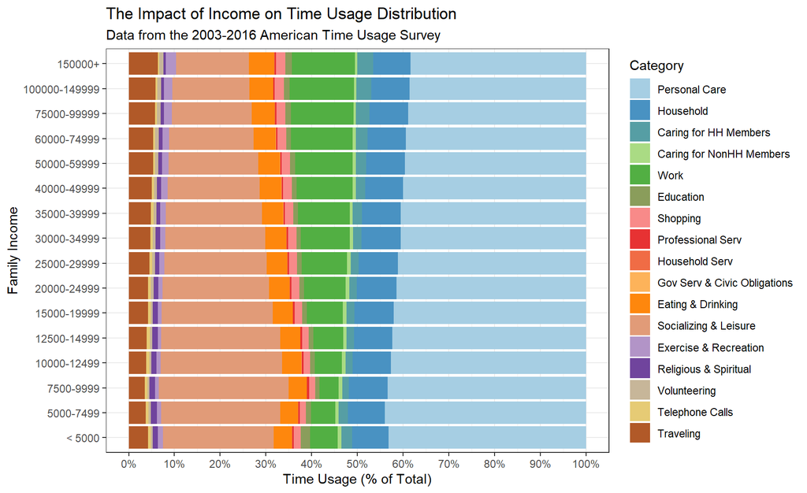

```r
time_data3$tier1 = as.factor(time_data3$tier1)
colourCount = length(unique(time_data3$tier1))
getPalette = colorRampPalette(brewer.pal(12, "Paired"))

ggplot(data = time_data3, mapping = aes(x = famincome, y = TDur,
                                                      fill = tier1)) +
  labs(title = "The Impact of Income on Time Usage Distribution",
       subtitle = "Data from the 2003-2016 American Time Usage Survey",
       y = "Time Usage (% of Total)", x = "Family Income") +
  scale_fill_brewer(palette = "Set1") +
  geom_col(position = "fill") +
  scale_y_continuous(breaks = seq(0.0, 1.0, 0.1), labels = function(x){
    paste0(x * 100, '%')}) +
  theme_bw()  +
  scale_fill_manual(name = "Category", labels = c("Personal Care", "Household",
                    "Caring for HH Members", "Caring for NonHH Members", "Work",
                    "Education", "Shopping", "Professional Serv",
                    "Household Serv", "Gov Serv & Civic Obligations",
                    "Eating & Drinking", "Socializing & Leisure",
                    "Exercise & Recreation", "Religious & Spiritual",
                    "Volunteering", "Telephone Calls", "Traveling"),
                    values = getPalette(colourCount)) +
  coord_flip()
```

Upon cursory inspection, it appears that as family income increases, people tend to spend less time on Personal Care (includes sleeping) and Socializing & Leisure related activities, while spending more time Traveling, on Exercise & Recreation, and on Work related activities.

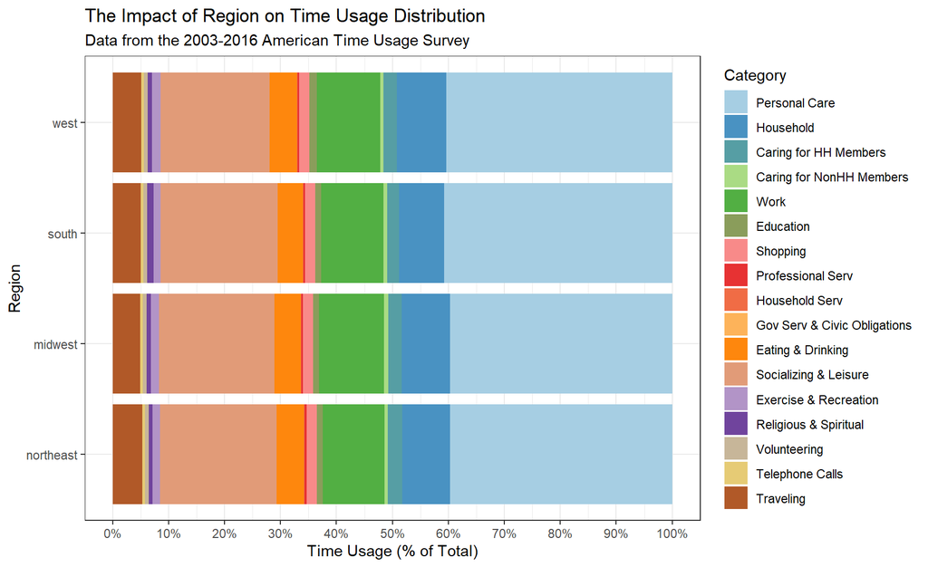

```r
time_data4$tier1 = as.factor(time_data4$tier1)
ggplot(data = time_data4, mapping = aes(x = region, y = RDur, fill = tier1)) +
  labs(title = "The Impact of Region on Time Usage Distribution",
       subtitle = "Data from the 2003-2016 American Time Usage Survey",
       y = "Time Usage (% of Total)", x = "Region") +
  geom_col(position = "fill") +
  scale_y_continuous(breaks = seq(0.0, 1.0, 0.1), labels = function(x){
    paste0(x * 100, '%')}) +
  theme_bw()  +
  scale_fill_manual(name = "Category", labels = c("Personal Care", "Household",
                    "Caring for HH Members", "Caring for NonHH Members", "Work",
                    "Education", "Shopping", "Professional Serv",
                    "Household Serv", "Gov Serv & Civic Obligations",
                    "Eating & Drinking", "Socializing & Leisure",
                    "Exercise & Recreation", "Religious & Spiritual",
                    "Volunteering", "Telephone Calls", "Traveling"),
                    values = getPalette(colourCount)) +
  coord_flip()
```

Looking at the resulting bar graph, it appears that region has little impact on time usage as the percentages of time spend on different types of activities across various regions of the United States line up almost perfectly. Although there are some slight deviations, for the most part it seems that region does not influence time usage significantly.

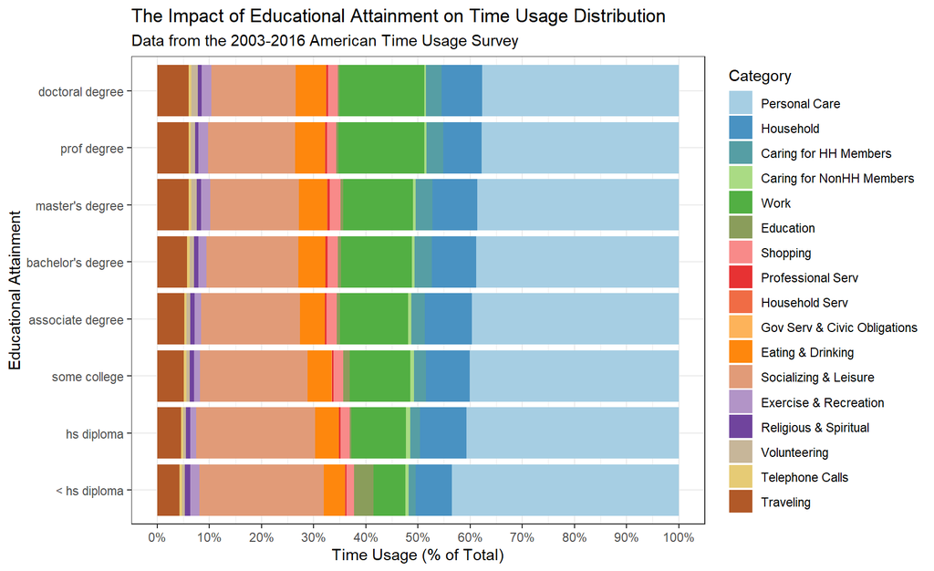

```r
time_data5$tier1 = as.factor(time_data5$tier1)
ggplot(data = time_data5, mapping = aes(x = edu, y = EDur, fill = tier1)) +
  labs(title = "The Impact of Educational Attainment on Time Usage Distribution",
       subtitle = "Data from the 2003-2016 American Time Usage Survey",
       y = "Time Usage (% of Total)", x = "Educational Attainment") +
  geom_col(position = "fill") +
  scale_y_continuous(breaks = seq(0.0, 1.0, 0.1), labels = function(x){
    paste0(x * 100, '%')}) +
  theme_bw()  +
  scale_fill_manual(name = "Category", labels = c("Personal Care", "Household",
                    "Caring for HH Members", "Caring for NonHH Members", "Work",
                    "Education", "Shopping", "Professional Serv",
                    "Household Serv", "Gov Serv & Civic Obligations",
                    "Eating & Drinking", "Socializing & Leisure",
                    "Exercise & Recreation", "Religious & Spiritual",
                    "Volunteering", "Telephone Calls", "Traveling"),
                    values = getPalette(colourCount)) +
  coord_flip()
```

As one might expect, the trends in the resulting bar graph seem to reflect those that appear in the graph for family income. It is well known that there is a strong correlation between these two variables so this is not that surprising. Most notable among the differences in the visual is that it appears that as educational attainment increases, people spend more time on Work and less time on Socializing & Leisure as well as on Personal Care. We saw these same exact trends in the graph for family income if you recall the result of the earlier code chunk.

## Analyzing Relationship Strength/Correlation

Now, we will fit and test various models on the datasets we have created to determine whether these demographics truly have a significant impact on the time usage of people in the ATUS. We will try a number of models and examine the results.

#### Linear Regression

We will start out by conducting some basic tests for linear regression.

```r
mod1 = lm(TDur ~ famincome, data = time_data3)
summary(mod1)
```

```
##
## Call:
## lm(formula = TDur ~ famincome, data = time_data3)
##
## Residuals:
##      Min       1Q   Median       3Q      Max
## -1885303  -797445  -378265  -101556 10611074
##
## Coefficients:
##                        Estimate Std. Error t value Pr(>|t|)
## (Intercept)              357747     413991   0.864  0.38832
## famincome5000-7499       -66123     585472  -0.113  0.91017
## famincome7500-9999        13159     585472   0.022  0.98209
## famincome10000-12499     132774     585472   0.227  0.82077
## famincome12500-14999      80370     585472   0.137  0.89092
## famincome15000-19999     345194     585472   0.590  0.55598
## famincome20000-24999     483598     585472   0.826  0.40957
## famincome25000-29999     501555     585472   0.857  0.39243
## famincome30000-34999     521621     585472   0.891  0.37380
## famincome35000-39999     434728     585472   0.743  0.45845
## famincome40000-49999     895620     585472   1.530  0.12732
## famincome50000-59999     846636     585472   1.446  0.14938
## famincome60000-74999    1085063     585472   1.853  0.06499 .
## famincome75000-99999    1533661     585472   2.620  0.00933 **
## famincome100000-149999   966683     585472   1.651  0.09994 .
## famincome150000+         583459     585472   0.997  0.31992
## ---
## Signif. codes:  0 '***' 0.001 '**' 0.01 '*' 0.05 '.' 0.1 ' ' 1
##
## Residual standard error: 1707000 on 256 degrees of freedom
## Multiple R-squared:  0.06503,    Adjusted R-squared:  0.01024
## F-statistic: 1.187 on 15 and 256 DF,  p-value: 0.2818
```

Somewhat unexpectedly based on our observations of the bar graph, it appears that family income is not as influential as we thought on peoples’ time usage. While the higher income brackets do show relatively low p-values, the only factor level that produces a p-value less than .05 is ‘famincome75000-99999’.

```r
mod2 = lm(RDur ~ region, data = time_data4)
summary(mod2)
```

```
##
## Call:
## lm(formula = RDur ~ region, data = time_data4)
##
## Residuals:
##      Min       1Q   Median       3Q      Max
## -5086741 -3044299 -2190062  -355643 30292027
##
## Coefficients:
##               Estimate Std. Error t value Pr(>|t|)
## (Intercept)    2423961    1563676   1.550    0.126
## regionmidwest  1011083    2211372   0.457    0.649
## regionsouth    2683688    2211372   1.214    0.229
## regionwest      691334    2211372   0.313    0.756
##
## Residual standard error: 6447000 on 64 degrees of freedom
## Multiple R-squared:  0.02427,    Adjusted R-squared:  -0.02146
## F-statistic: 0.5307 on 3 and 64 DF,  p-value: 0.6628
```

As we expected from the graph we generated, region has little impact on time usage. None of the p-values for the regions are below .05.

```r
mod3 = lm(EDur ~ edu, data = time_data5)
summary(mod3)
```

```
##
## Call:
## lm(formula = EDur ~ edu, data = time_data5)
##
## Residuals:
##      Min       1Q   Median       3Q      Max
## -3625966 -1980998  -640999     5120 21502217
##
## Coefficients:
##                      Estimate Std. Error t value Pr(>|t|)
## (Intercept)           2195607     906423   2.422   0.0168 *
## eduhs diploma         1443162    1281876   1.126   0.2623
## edusome college        306506    1281876   0.239   0.8114
## eduassociate degree   -894382    1281876  -0.698   0.4866
## edubachelor's degree   588046    1281876   0.459   0.6472
## edumaster's degree    -989201    1281876  -0.772   0.4417
## eduprof degree       -1974559    1281876  -1.540   0.1259
## edudoctoral degree   -1962477    1281876  -1.531   0.1283
## ---
## Signif. codes:  0 '***' 0.001 '**' 0.01 '*' 0.05 '.' 0.1 ' ' 1
##
## Residual standard error: 3737000 on 128 degrees of freedom
## Multiple R-squared:  0.09105,    Adjusted R-squared:  0.04134
## F-statistic: 1.832 on 7 and 128 DF,  p-value: 0.08655
```

Again, somewhat surprising results based on the appearance of our graph. The p-values for the various educational attainments are even worse than those for family income and none possess a value below .05.

#### Multi-variable Linear Regression

Lets try grouping the dataset observations by tier, famincome, region, and edu to see if we find anything different.

```r
time_data6 = time_data2 %>%
  group_by(tier1, famincome, region, edu) %>%
  mutate(Dur = sum(dur)) %>%
  select(tier1, famincome, region, edu, Dur) %>%
  distinct()
time_data6
```

| tier1 | famincome | region | edu | Dur |
| --- | --- | --- | --- | --- |
| 1 | 60000-74999 | west | master's degree | 216538 |
| 1 | 75000-99999 | west | associate degree | 284467 |
| 1 | 20000-24999 | south | hs diploma | 888763 |
| 1 | 75000-99999 | south | prof degree | 87855 |
| 1 | 40000-49999 | south | bachelor's degree | 575346 |
| 1 | 12500-14999 | south | hs diploma | 451271 |
| 1 | 75000-99999 | midwest | some college | 491795 |
| 1 | 50000-59999 | midwest | associate degree | 260638 |
| 1 | 25000-29999 | northeast | associate degree | 72118 |
| 1 | 30000-34999 | northeast | some college | 141017 |

[output cut: 8042 more lines]

```r
mod4 = lm(Dur ~ famincome + region + edu, data = time_data6)
summary(mod4)
```

```
##
## Call:
## lm(formula = Dur ~ famincome + region + edu, data = time_data6)
##
## Residuals:
##     Min      1Q  Median      3Q     Max
## -102071  -31548  -13718    4322 1128166
##
## Coefficients:
##                         Estimate Std. Error t value Pr(>|t|)
## (Intercept)              8427.54    4231.86   1.991 0.046465 *
## famincome5000-7499      -3816.35    4879.66  -0.782 0.434183
## famincome7500-9999         55.08    4818.25   0.011 0.990879
## famincome10000-12499     4193.11    4808.21   0.872 0.383194
## famincome12500-14999     2620.55    4779.92   0.548 0.583541
## famincome15000-19999    11843.57    4760.34   2.488 0.012868 *
## famincome20000-24999    16398.60    4736.64   3.462 0.000539 ***
## famincome25000-29999    16975.94    4734.40   3.586 0.000338 ***
## famincome30000-34999    17600.74    4714.12   3.734 0.000190 ***
## famincome35000-39999    14753.03    4727.50   3.121 0.001811 **
## famincome40000-49999    29370.38    4671.28   6.287 3.40e-10 ***
## famincome50000-59999    27975.38    4675.53   5.983 2.28e-09 ***
## famincome60000-74999    35430.09    4673.16   7.582 3.79e-14 ***
## famincome75000-99999    49180.31    4651.05  10.574  < 2e-16 ***
## famincome100000-149999  31659.31    4659.33   6.795 1.16e-11 ***
## famincome150000+        19701.79    4659.55   4.228 2.38e-05 ***
## regionmidwest            8514.51    2351.50   3.621 0.000295 ***
## regionsouth             22214.56    2337.50   9.504  < 2e-16 ***
## regionwest               5875.65    2346.52   2.504 0.012300 *
## eduhs diploma           22456.89    3200.04   7.018 2.44e-12 ***
## edusome college          4728.70    3204.49   1.476 0.140078
## eduassociate degree    -14254.41    3212.78  -4.437 9.25e-06 ***
## edubachelor's degree     9207.77    3207.50   2.871 0.004106 **
## edumaster's degree     -15479.89    3244.43  -4.771 1.86e-06 ***
## eduprof degree         -32806.64    3439.43  -9.538  < 2e-16 ***
## edudoctoral degree     -32875.96    3429.05  -9.587  < 2e-16 ***
## ---
## Signif. codes:  0 '***' 0.001 '**' 0.01 '*' 0.05 '.' 0.1 ' ' 1
##
## Residual standard error: 74240 on 8026 degrees of freedom
## Multiple R-squared:  0.09374,    Adjusted R-squared:  0.09092
## F-statistic: 33.21 on 25 and 8026 DF,  p-value: < 2.2e-16
```

The results of this tests are still rather confusing as the p-values don’t line up with the results from earlier tests. The results show both educational attainment and region as having significant impact on time usage despite the results of the earlier tests. Based on this test the most significant predictors are certain levels of each factor. These levels include edudoctoral degree, eduprof degree, regionsouth, and famincome 75000-99999.

## Conclusion

Overall, based on the results of the tests and the graphics generated, I think that it is difficult to reach a decisive decision on the impact of the demographic variables Family Income, Region, and Educational Attainment on Time Usage. However, I would say that it seems these three variables do not have that significant of an impact on Time Usage. If I were to rank the impact of the variables it would likely go Family Income, Educational Attainment, and then finally Region.

## My Contributions

I did the data manipulation, generated graphics, and ran statistical tests on the relationships between Time Usage and the demographics of Family Income, Region, and Educational Attainment

Note: I used the bad_drivers dataset for part 1 of the final project